# Project 4

CyberBoolin

2022-09-28

## Introduction

The main goal of this project is to look at the morphological and allometric difference between the different ecomorphs within the genus *Anolis*. The term ecomorph was created by evolutionary biologist and herpetologist Ernest Edward Williams, using the genus *Anolis* as his model. ‘Ecomorph’ means a group of species with a similar ecological niche and behavior within said niche. For the *Anolis* genus, we will be assessing the relationship between hind limb length and size, based on a recent study by Hagey et al. (2017) in the context of their niche, using a variety of visualization methods.

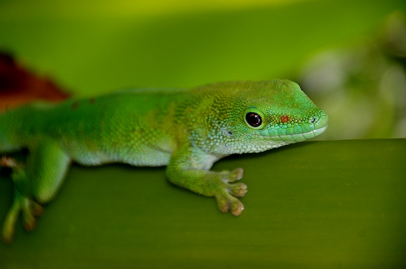

## Methods

First, an anole.log data tibble was established, followed by the construction of two linear models using the log-transformed data from anole.log that showed the effect of perch height and diameter as covariates.

Finally, a plot was produced that visualizes the effect of the covariates and factors on the hindlimb residuals of the best fitting PGLS model.

## Results

AIC of BM and BM and OU PGLS Models Considering Ecomorph of *Anolis*

|  | df | AICc |
| --- | --- | --- |
| pgls.BM1 | 3 | -63.66118 |
| pgls.BM2 | 13 | -92.98036 |
| pgls.OU1 | 4 | -57.31864 |
| pgls.OU2 | 14 | -84.89770 |

AIC of BM and OU PGLS Models Considering Ecomorph of *Anolis*

| fit | delta | w | models |
| --- | --- | --- | --- |
| -63.66118 | 29.319176 | 0.0000004 | pgls.BM1 |
| -92.98036 | 0.000000 | 0.9827289 | pgls.BM2 |
| -57.31864 | 35.661714 | 0.0000000 | pgls.OU1 |
| -84.89770 | 8.082653 | 0.0172706 | pgls.OU2 |

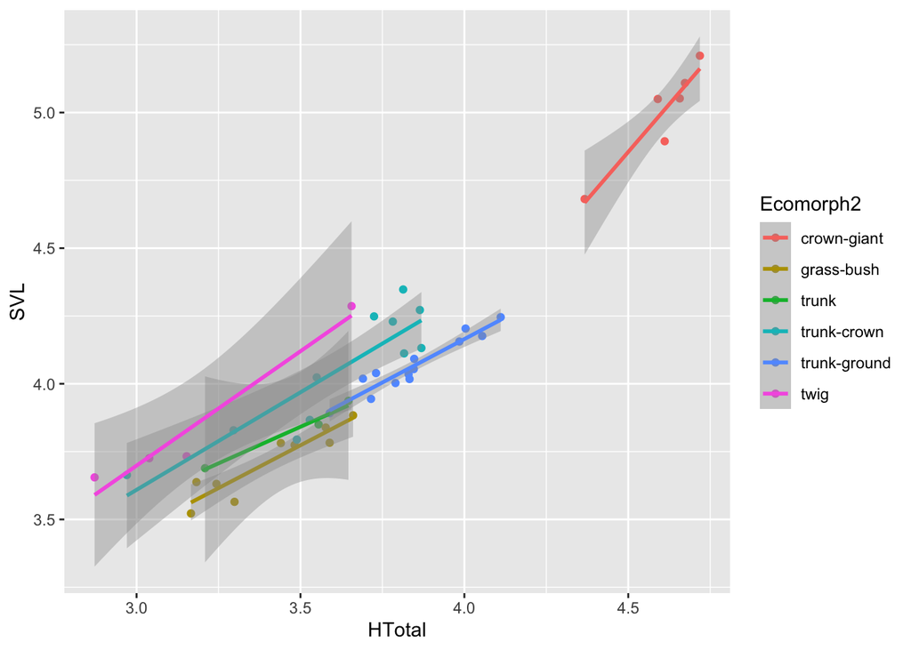

Regression Plot of Log-transformed HTotal vs. SVL by Ecomorphs

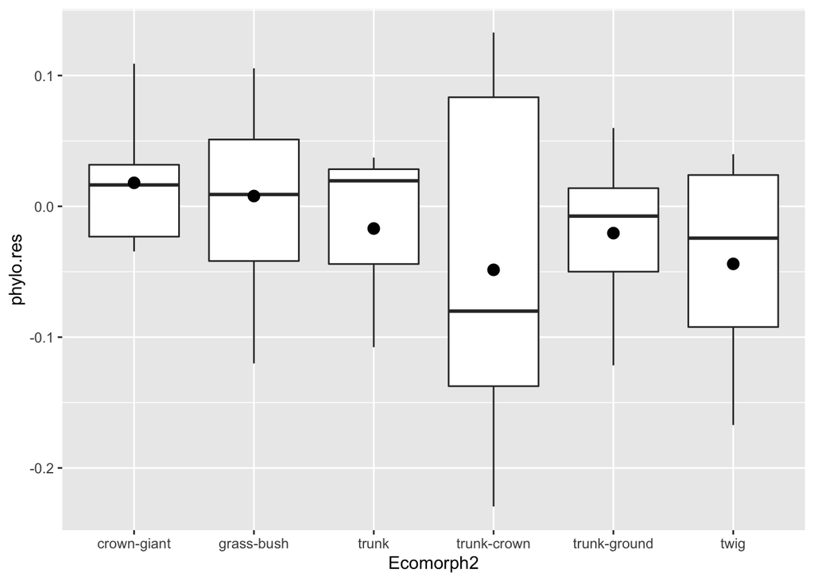

Boxplot of phylogenetically corrected hindlimb residuals versus anole ecomorph

## Discussion

From the results of the PGLS models in addition to the analysis of the best fitting PGLS model, we decided that the PGLS under the Brownian Motion model including ecomorphs (PGLS.BM2) has the best fit. With this, we can arrive at the conclusion that ecomorphs have an impact on the relationship between snout-vent length and hindlimb length. Because the Brownian model has a better fit than the OU model, and because it is phylogenetically corrected, we can conclude that the traits evolved randomly, as well as randomly within each lineage.

## Author Contributions

Rachel Zhu worked on the the intro and the code chunks to produce the AIC values table, the methods, the author contributions and references section. Adam Qu worked on the regression plot of log-transformed Htotal vs SVL figure, the results, and the discussion.

## References

Hagey, Travis J, Scott Harte, Mathew Vickers, Luke J Harmon, and Lin Schwarzkopf. 2017. “There’s More Than One Way to Climb a Tree: Limb Length and Microhabitat Use in Lizards with Toe Pads.” *PLoS One* 12 (9): e0184641.

Poe, Steven, Adrian Nieto-Montes de Oca, Omar Torres-Carvajal, Kevin De Queiroz, Julián A Velasco, Brad Truett, Levi N Gray, et al. 2017. “A Phylogenetic, Biogeographic, and Taxonomic Study of All Extant Species of Anolis (Squamata; Iguanidae).” *Systematic Biology* 66 (5): 663–97.